# AE 20: Response to Leukemia Treatment

Prediction + Conditions

2020-10-21

## Announcements

### Tea with a TA!

Hang out with the TAs from STA 210! This is a casual conversation and a fun opportunity to meet the members of the STA 210 teaching team. The only rule is these can’t turn into office hours!

Tea with a TA counts as a statistics experience.

- [**Meredith Brown**](https://meredithb3.github.io/), Tue, Oct 27 at 7p
  - [Click here](https://forms.gle/fx3rUyhSYTZ9EmnE7) to sign up. Zoom details will be emailed before the event.

### This is Statistics Fall Data Challenge

[Click here](https://thisisstatistics.org/falldatachallenge/) for details on the Get out the Vote! Fall Data Challenge by the American Statistical Association (ASA). Submissions are due **November 11**.

### Big data and public policy event on Oct 26

### Final project - Draft due Oct 28

- Write the draft in the `written-report.Rmd` file in the project repo.
- Draft should include
  - exploratory data analysis
  - initial model selection (main effects + interactions)
  - initial interpretations / conclusions from model

### Quiz 03

- Available Thu, Oct 22 at 12a - Fri, Oct 23 11:59p
- 2 hours to complete it
- Covers material weeks 07 - 09
- No office hours Oct 22 - Oct 23. Piazza will be inactive while the quiz is out.
- No lab this week.

## Response to Leukemia treatment

Today’s data is from a study where 51 untreated adult patients with acute myeloblastic leukemia who were given a course of treatment, and they were assessed as to their response to the treatment.[^1]

The goal of today’s analysis is to use pre-treatment to predict how likely it is a patient will respond to the treatment.

We will use the following variables:

- `Age`: Age at diagnosis (in years)
- `Smear`: Differential percentage of blasts
- `Infil`: Percentage of absolute marrow leukemia infiltrate
- `Index`: Percentage labeling index of the bone marrow leukemia cells
- `Blasts`: Absolute number of blasts, in thousands
- `Temp`: Highest temperature of the patient prior to treatment, in degrees Fahrenheit
- `Resp`: 1 = responded to treatment or 0 = failed to respond

We want to use the `Age`, `Index` and `Temp` to predict the odds a patient will respond to the treatment. The model is below.

| term | estimate | std.error | statistic | p.value |
| --- | --- | --- | --- | --- |
| (Intercept) | 87.388 | 35.458 | 2.465 | 0.014 |
| Age | -0.059 | 0.026 | -2.287 | 0.022 |
| Index | 0.385 | 0.122 | 3.168 | 0.002 |
| Temp | -0.089 | 0.036 | -2.467 | 0.014 |

Ultimately, we want to use the model to classify patients into two groups: those who are likely to respond to the treatment and those are not. To do so, we’ll fit an ROC curve to help us determine a decision-making threshold.

```
## # A tibble: 5 x 4
##   .threshold specificity sensitivity pred_prob
##        <dbl>       <dbl>       <dbl>     <dbl>
## 1    -Inf         0                1   0
## 2      -6.49      0                1   0.00151
## 3      -5.35      0.0370           1   0.00474
## 4      -5.33      0.0741           1   0.00484
## 5      -5.21      0.111            1   0.00545
```

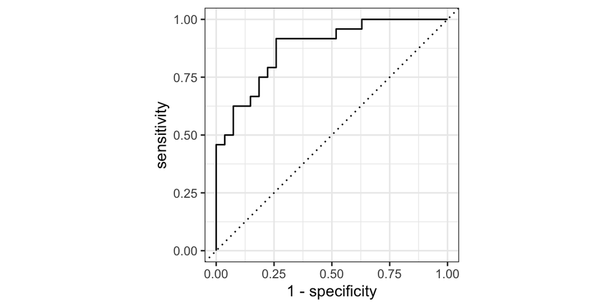

1. Suppose a doctor wants to use your model to determine if she should recommend this particular treatment for her patients with leukemia. Based on the data from the ROC curve, what decision-making threshold do you recommend the doctor use to select patients for this treatment? What factors did you consider to determine the threshold?
2. Check the model conditions - linearity, randomness, independence. *Recall you may need to install the Stat2Data package.*
[^1]: The data set is from the Stat2Data R package